# DATA 609 - HW 8

Betsy Rosalen

December 12, 2021

## Ex. 1

### Use the `nnet()` package to analyze the `iris` data set. Use 80% of the 150 samples as the training data and the rest for validation. Discuss the results.

```r
i <- iris
i
```

| Sepal.Length | Sepal.Width | Petal.Length | Petal.Width | Species |
| --- | --- | --- | --- | --- |
| 5.1 | 3.5 | 1.4 | 0.2 | setosa |
| 4.9 | 3.0 | 1.4 | 0.2 | setosa |
| 4.7 | 3.2 | 1.3 | 0.2 | setosa |
| 4.6 | 3.1 | 1.5 | 0.2 | setosa |
| 5.0 | 3.6 | 1.4 | 0.2 | setosa |
| 5.4 | 3.9 | 1.7 | 0.4 | setosa |
| 4.6 | 3.4 | 1.4 | 0.3 | setosa |
| 5.0 | 3.4 | 1.5 | 0.2 | setosa |
| 4.4 | 2.9 | 1.4 | 0.2 | setosa |
| 4.9 | 3.1 | 1.5 | 0.1 | setosa |

[output cut: 140 more lines]

```r
samp <- c(sample(1:50,40), sample(51:100,40), sample(101:150,40))
train <- i[samp,]
test <- i[-samp,]

iris_nnet <- nnet(Species~., train, size = 2, rang = 0.1,
            decay = 5e-4, maxit = 200)
i_pred <- as.factor(predict(iris_nnet, test, 'class'))
confusionMatrix(i_pred, test$Species)
```

```
## Confusion Matrix and Statistics
##
##             Reference
## Prediction   setosa versicolor virginica
##   setosa         10          0         0
##   versicolor      0         10         0
##   virginica       0          0        10
##
## Overall Statistics
##
##                Accuracy : 1
##                  95% CI : (0.884, 1)
##     No Information Rate : 0.333
##     P-Value [Acc > NIR] : 0.00000000000000486
##
##                   Kappa : 1
##
##  Mcnemar's Test P-Value : NA
##
## Statistics by Class:
##
##                      Class: setosa Class: versicolor Class: virginica
## Sensitivity                  1.000             1.000            1.000
## Specificity                  1.000             1.000            1.000
## Pos Pred Value               1.000             1.000            1.000
## Neg Pred Value               1.000             1.000            1.000
## Prevalence                   0.333             0.333            0.333
## Detection Rate               0.333             0.333            0.333
## Detection Prevalence         0.333             0.333            0.333
## Balanced Accuracy            1.000             1.000            1.000
```

##### I used the help documentation in R to understand how to use `nnet` and they had used the `iris` data set as their example, so I chose to use the same hyperparameters as in their example. I wish I knew *why* they chose those hyperparaeter values rather than the defaults though. Let’s run it again using the defaults to see what happens…

```r
set.seed(42)
iris_nnet2 <- nnet(Species~., train, size = 1)
i_pred2 <- as.factor(predict(iris_nnet2, test, 'class'))
confusionMatrix(i_pred2, test$Species)
```

```
## Confusion Matrix and Statistics
##
##             Reference
## Prediction   setosa versicolor virginica
##   setosa         10          0         0
##   versicolor      0          0         0
##   virginica       0         10        10
##
## Overall Statistics
##
##                Accuracy : 0.667
##                  95% CI : (0.472, 0.827)
##     No Information Rate : 0.333
##     P-Value [Acc > NIR] : 0.000194
##
##                   Kappa : 0.5
##
##  Mcnemar's Test P-Value : NA
##
## Statistics by Class:
##
##                      Class: setosa Class: versicolor Class: virginica
## Sensitivity                  1.000             0.000            1.000
## Specificity                  1.000             1.000            0.500
## Pos Pred Value               1.000               NaN            0.500
## Neg Pred Value               1.000             0.667            1.000
## Prevalence                   0.333             0.333            0.333
## Detection Rate               0.333             0.000            0.333
## Detection Prevalence         0.333             0.000            0.667
## Balanced Accuracy            1.000             0.500            0.750
```

##### I got really inconsistent results using the defaults and size=1 (above). So I set a seed to show the problem. You can see above using 42 as my seed one third of the test set are misclassified. However if I use seed 250 (below) then I get almost the same performance as in the first model above which gave consistently good results no matter how many times I ran it. So clearly the customized hyperparameters result in a much better and more consistent model.

```r
set.seed(250)
iris_nnet2 <- nnet(Species~., train, size = 1)
i_pred2 <- as.factor(predict(iris_nnet2, test, 'class'))
confusionMatrix(i_pred2, test$Species)
```

```
## Confusion Matrix and Statistics
##
##             Reference
## Prediction   setosa versicolor virginica
##   setosa         10          0         0
##   versicolor      0         10         0
##   virginica       0          0        10
##
## Overall Statistics
##
##                Accuracy : 1
##                  95% CI : (0.884, 1)
##     No Information Rate : 0.333
##     P-Value [Acc > NIR] : 0.00000000000000486
##
##                   Kappa : 1
##
##  Mcnemar's Test P-Value : NA
##
## Statistics by Class:
##
##                      Class: setosa Class: versicolor Class: virginica
## Sensitivity                  1.000             1.000            1.000
## Specificity                  1.000             1.000            1.000
## Pos Pred Value               1.000             1.000            1.000
## Neg Pred Value               1.000             1.000            1.000
## Prevalence                   0.333             0.333            0.333
## Detection Rate               0.333             0.333            0.333
## Detection Prevalence         0.333             0.333            0.333
## Balanced Accuracy            1.000             1.000            1.000
```

## Ex. 2

### As a mini project, install the `keras` package and learn how to use it. Then, carry out various tasks that may be useful to your project and studies.

##### I used the cran documentation to learn about using the keras package. Most of the code is modified from this page: https://cran.r-project.org/web/packages/keras/vignettes/index.html

#### Downloading and preparing the data

##### I decided to use the alternative fashion dataset though instead of MNIST. The following code loads the dataset:

```r
fashion <- dataset_fashion_mnist()
```

#### First 4 images

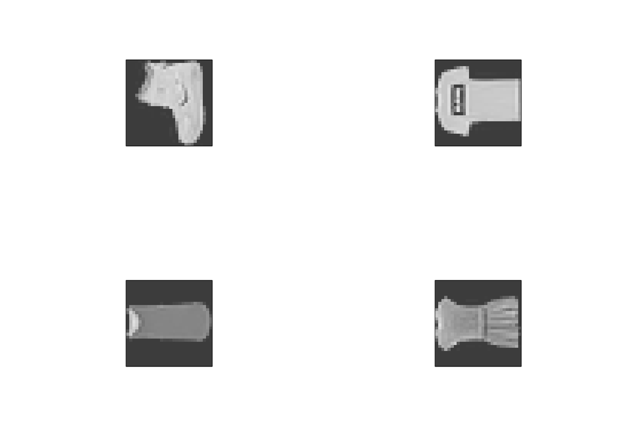

##### Here’s a description of the dataset from the `keras` package documentation found here: https://cran.r-project.org/web/packages/keras/keras.pdf

##### **Details**

Dataset of 60,000 28x28 grayscale images of 10 fashion categories, along with a test set of 10,000 images. This dataset can be used as a drop-in replacement for MNIST. The class labels are:

- 0 - T-shirt/top
- 1 - Trouser
- 2 - Pullover
- 3 - Dress
- 4 - Coat
- 5 - Sandal
- 6 - Shirt
- 7 - Sneaker
- 8 - Bag
- 9 - Ankle boot

##### **Value**

Lists of training and test data: train$x, train$y, test$x, test$y, where x is an array of grayscale image data with shape (num_samples, 28, 28) and y is an array of article labels (integers in range 0-9) with shape (num_samples).

##### The data is already split into training and testing sets but the x values need to be reshaped from 3-d arrays to 1-d vectors and scaled so that the values range from 0 to 1 instead of 0 to 255 (grayscale values) and the y values need to be one-hot encoded into binary class matrices using the Keras `to_categorical()` function.

```r
x_train <- fashion$train$x
y_train <- fashion$train$y
x_test <- fashion$test$x
y_test <- fashion$test$y
```

```r
# reshape
x_train <- array_reshape(x_train, c(nrow(x_train), 784))
x_test <- array_reshape(x_test, c(nrow(x_test), 784))
# rescale
x_train <- x_train / 255
x_test <- x_test / 255

y_train <- to_categorical(y_train, 10)
y_test <- to_categorical(y_test, 10)
```

#### Defining and training the model

##### Now that the data is ready, we can define a model. For the first model I just used the parameters exactly as I found them in the keras documentation example. Then I iterated through a range of changes to the hyperparameters and the number of layers to see if I could impove upon the model. The code is shown for the first model but just the plots for the subsequent models.

#### Model 1 - 2 layers 256/128 units each, batch size 128, 30 epochs

```r
model <- keras_model_sequential()
model %>%
  layer_dense(units = 256, activation = 'relu', input_shape = c(784)) %>%
  layer_dropout(rate = 0.4) %>%
  layer_dense(units = 128, activation = 'relu') %>%
  layer_dropout(rate = 0.3) %>%
  # outputs a length 10 numeric vector (probabilities for each class) using a softmax activation function.
  layer_dense(units = 10, activation = 'softmax')
```

```r
summary(model)
```

```
## Model: "sequential"
## ________________________________________________________________________________
##  Layer (type)                       Output Shape                    Param #
## ================================================================================
##  dense_2 (Dense)                    (None, 256)                     200960
##
##  dropout_1 (Dropout)                (None, 256)                     0
##
##  dense_1 (Dense)                    (None, 128)                     32896
##
##  dropout (Dropout)                  (None, 128)                     0
##
##  dense (Dense)                      (None, 10)                      1290
##
## ================================================================================
## Total params: 235,146
## Trainable params: 235,146
## Non-trainable params: 0
## ________________________________________________________________________________
```

```r
model %>% compile(
  loss = 'categorical_crossentropy',
  optimizer = optimizer_rmsprop(),
  metrics = c('accuracy')
)
```

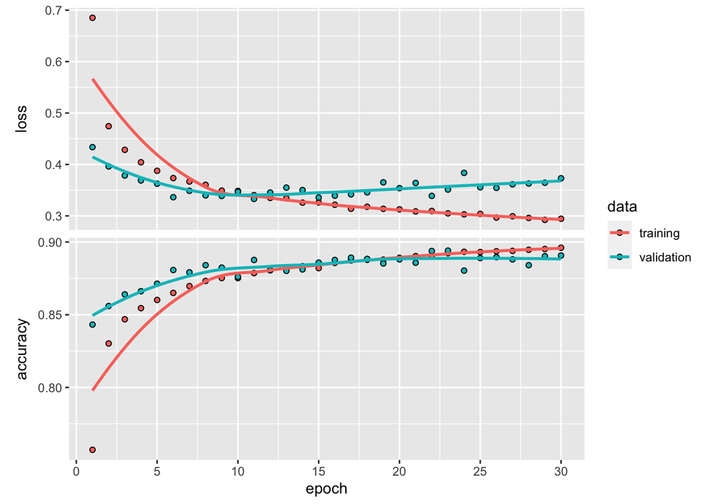

```r
set.seed(42)
history <- model %>% fit(
  x_train, y_train,
  epochs = 30, batch_size = 128,
  validation_split = 0.2
)

plot(history)
```

```r
model %>% evaluate(x_test, y_test)
```

```
##     loss accuracy
##   0.4072   0.8853
```

#### Model 2 - 2 layers 256/128 units each, batch size 256, 30 epochs

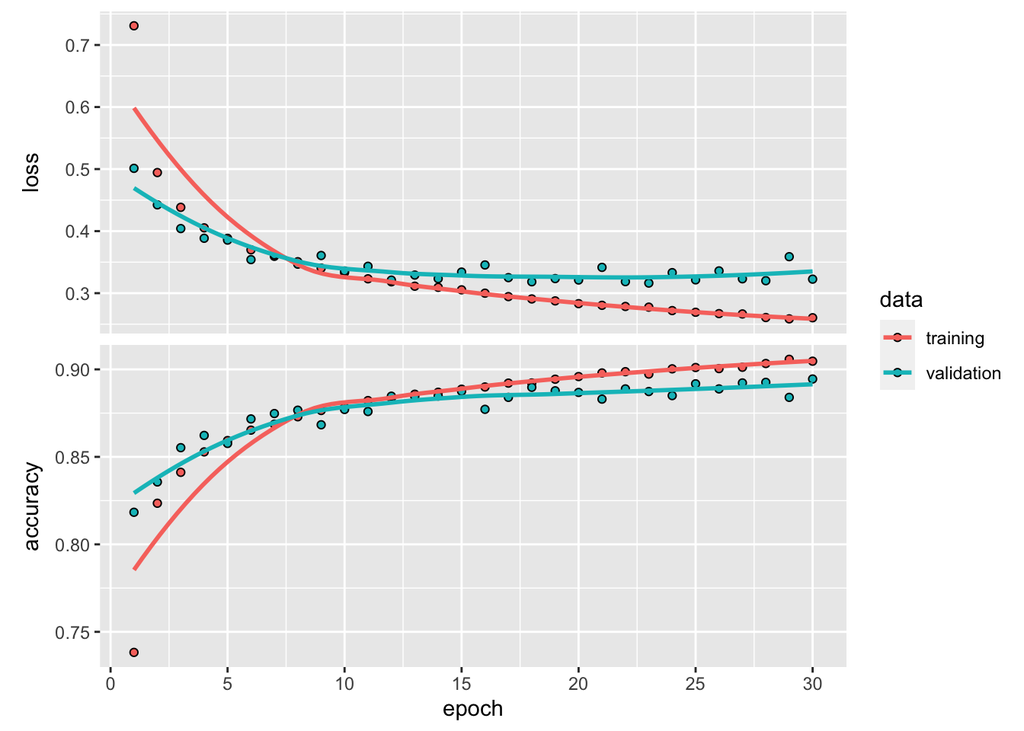

```
##     loss accuracy
##   0.3508   0.8850
```

#### Model 3 - 2 layers 256/128 units each, batch size 64, 30 epochs

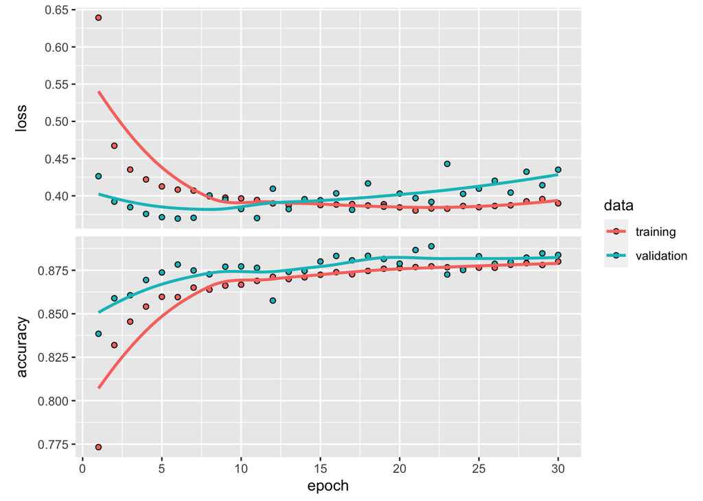

```
##     loss accuracy
##   0.4908   0.8771
```

#### Model 4 - 2 layers 128/64 units each, batch size 128, 30 epochs

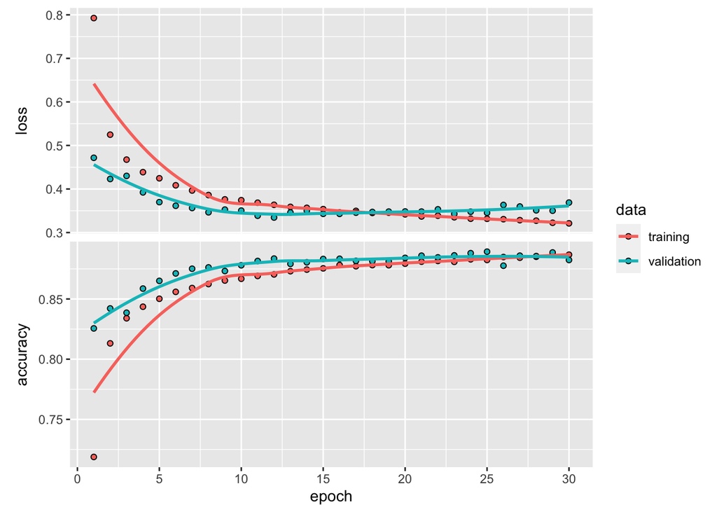

```
##     loss accuracy
##   0.4074   0.8721
```

#### Model 5 - 2 layers 128/64 units each, batch size 256, 30 epochs

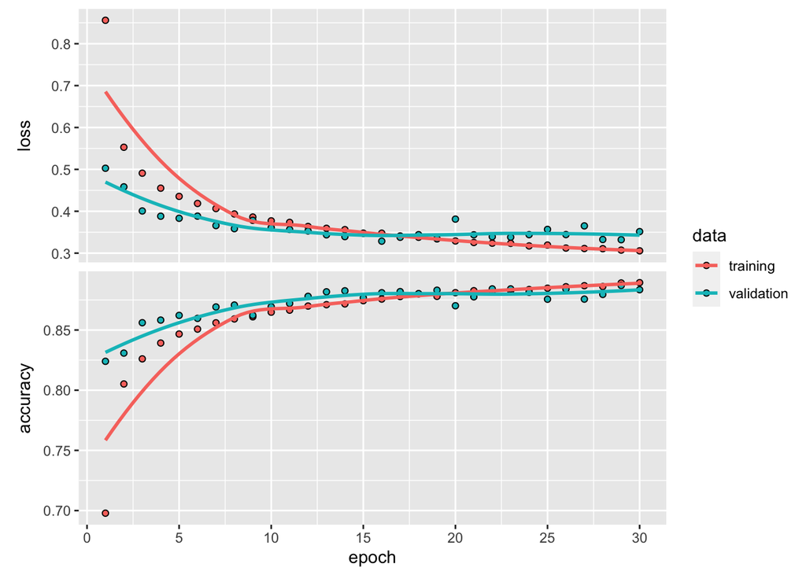

```
##     loss accuracy
##   0.3729   0.8753
```

#### Model 6 - 2 layers 64/32 units each, batch size 256, 30 epochs

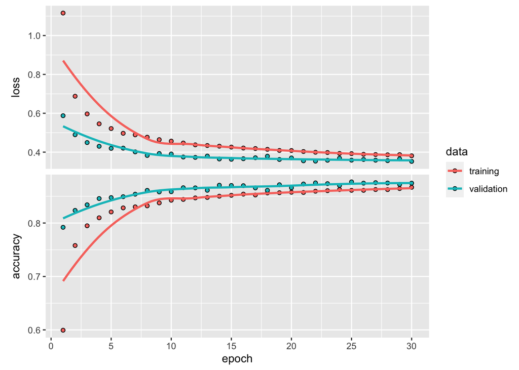

```
##     loss accuracy
##   0.3802   0.8678
```

#### Model 7 - 3 layers 128/64/32 units each, batch size 256, 30 epochs

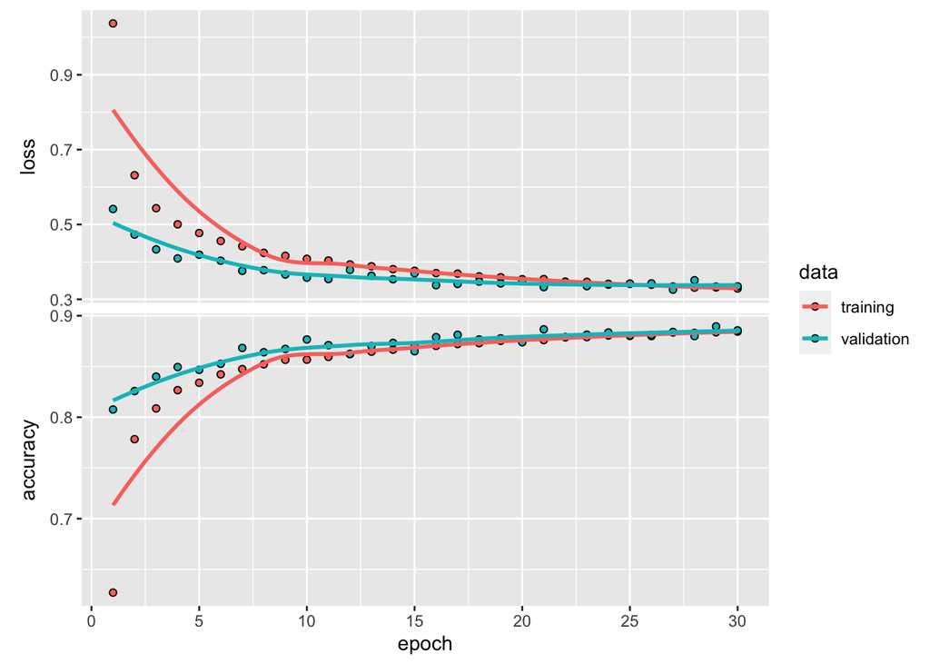

```
##     loss accuracy
##   0.3720   0.8766
```

#### Model 8 - 3 layers 256/128/64 units each, batch size 512, 30 epochs

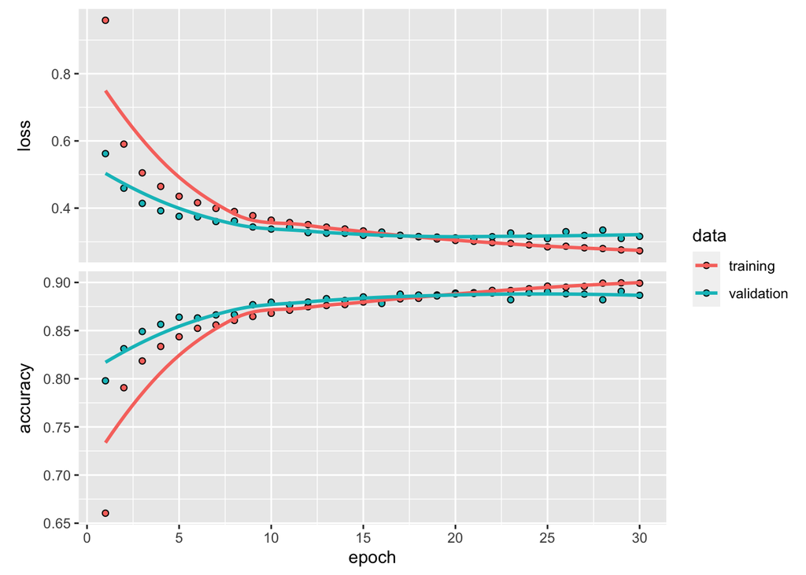

```
##     loss accuracy
##   0.3413   0.8832
```

#### Evaluation

```r
pred <- model7 %>% predict(x_test) %>% k_argmax() %>% as.numeric() %>% as.factor()
y_transformed <- (as.numeric(sub('.', '', names(as.data.frame(y_test))[max.col(y_test)]))-1) %>% as.factor()
confusionMatrix(pred, y_transformed)
```

```
## Confusion Matrix and Statistics
##
##           Reference
## Prediction   0   1   2   3   4   5   6   7   8   9
##          0 804   0  13  21   0   0 119   0   1   0
##          1   2 959   1   4   0   0   1   0   0   0
##          2  16   3 747   7  74   0  79   0   5   0
##          3  55  30  16 922  45   1  47   0   4   0
##          4   7   3 133  24 809   0  66   0   3   0
##          5   1   0   0   0   0 954   0  12   1   7
##          6 103   2  87  16  68   0 677   0   6   1
##          7   1   0   0   0   0  32   0 975   5  48
##          8  11   3   3   6   4   2  11   0 975   0
##          9   0   0   0   0   0  11   0  13   0 944
##
## Overall Statistics
##
##                Accuracy : 0.877
##                  95% CI : (0.87, 0.883)
##     No Information Rate : 0.1
##     P-Value [Acc > NIR] : <0.0000000000000002
##
##                   Kappa : 0.863
##
##  Mcnemar's Test P-Value : NA
##
## Statistics by Class:
##
##                      Class: 0 Class: 1 Class: 2 Class: 3 Class: 4 Class: 5
## Sensitivity            0.8040   0.9590   0.7470   0.9220   0.8090   0.9540
## Specificity            0.9829   0.9991   0.9796   0.9780   0.9738   0.9977
## Pos Pred Value         0.8392   0.9917   0.8024   0.8232   0.7742   0.9785
## Neg Pred Value         0.9783   0.9955   0.9721   0.9912   0.9787   0.9949
## Prevalence             0.1000   0.1000   0.1000   0.1000   0.1000   0.1000
## Detection Rate         0.0804   0.0959   0.0747   0.0922   0.0809   0.0954
## Detection Prevalence   0.0958   0.0967   0.0931   0.1120   0.1045   0.0975
## Balanced Accuracy      0.8934   0.9791   0.8633   0.9500   0.8914   0.9758
##                      Class: 6 Class: 7 Class: 8 Class: 9
## Sensitivity            0.6770   0.9750   0.9750   0.9440
## Specificity            0.9686   0.9904   0.9956   0.9973
## Pos Pred Value         0.7052   0.9189   0.9606   0.9752
## Neg Pred Value         0.9643   0.9972   0.9972   0.9938
## Prevalence             0.1000   0.1000   0.1000   0.1000
## Detection Rate         0.0677   0.0975   0.0975   0.0944
## Detection Prevalence   0.0960   0.1061   0.1015   0.0968
## Balanced Accuracy      0.8228   0.9827   0.9853   0.9707
```